# BMEB W4020 Project #2 Handout

The goal of this project is to implement a decoding algorithm for the olfactory processing pathway of *Drosophila Malenogaster* (fruitfly). Specifically, you are asked to implement a simple model of an olfactory channel in fruit flies as shown below:

[figure not shown]

## I/O Relationship

### Input $u(t)$

An odor with a concentration profile $u=u(t)$, $t \in [0, 500]$(in ms) is sensed by some 40 to 50 olfactory sensory neurons (OSNs).

Assume that the stimulus concentration at the input of the OSNs is modeled as a bandlimited function of the form $$ u(t)= \sum_{k=1}^{15} u(kT) \frac{\sin \Omega (t-kT)}{\Omega (t-kT)}, $$ where $\Omega = 2 \pi \cdot 25$ Hz and $T=\frac{\pi}{\Omega}$.

### 1st Layer: Olfactory Sensory Neurons (OSNs): $u(t) \rightarrow (t_k^{m}), m = 1,\ldots M$

The input $u(t)$ is first processed by the OSNs in a SIMO fashion (a scaled up version of the HW4-P2). Each parallel processing pathway is modeled as a [Filter]-[PIF] circuit.

1. The temporal receptive fields of the OSNs are of the form $$ h^i (t) = h_{max}^i \exp(-\frac{t}{\tau^i}) $$ for $t \geq 0$ and zero otherwise.
2. All neurons are modeled as IAF neurons. See **Project Details** for information about the requirement of the IAF neurons.

### 2nd Layer: Glomeruli: $\{(t_k^{m})\}_{m} \rightarrow \{v^{1n}\}_{n}, m = 1,\ldots M, n = 1,\ldots N$

The output spike $(t_{k}^{m})$ trains from the OSNs ($1,\ldots, M$) are processed in a region called the Glomeruli in the *Antennal Lobe*. Glomerular synapses are modeled as $\alpha$-functions of the form $$ h^{ij}(t)= h_{max}^{ij} \frac{t}{\tau^{ij}}\exp(1- 50\frac{t}{\tau^{ij}}) $$

### 3rd Layer: Projection Neurons (PNs): $v^{1n} \rightarrow (t_k^{1n}), n = 1,\ldots N$

The output of the glomeruli are mapped into distinctive projection neurons, 10-20 PNs.

1. All neurons are modeled as IAF neurons. See **Project Details** for information about the requirement of the IAF neurons.

## Project Details:

1. Realize the circuit shown in figure above. Choose the parameters of the IAF neurons such that the average number of spikes for OSNs is below 50 and PNs is below 100 spikes/s. Specify the average spike rate of every neuron in the circuit above. Assume that $\tau^i$ is *uniformly distributed* in the time interval $[15, 25]$ (ms) and that $\tau^{ij}$ is *uniformly distributed* on the time interval $[350, 450]$ (ms) for all $i = 1,2, ... , N,$ and $j=1,2,...,M$. Further assume that $h^{i}_{max},h^{ij}_{max}$ is *uniformly distributed* in the range $[1,5]$.
   - Produce the following plots (can be in a subplot):
     1. Input $u(t)$, pick one of the filters $h^{i}(t)$ and filtered input $v^{i}$
     2. OSN spiking, using the `utils.plotRaster` function
     3. OSN spike rates, also draw a line indicating 50 Hz
     4. Glomeruli filter $h^{nm}$, output $v^{1n}$, plot a number of filters and outputs that you consider appropriate
     5. PN spiking, using the `utils.plotRaster` function
     6. PN spike rates, also draw a line indicating 100 Hz
2. Recover the odor stimulus $u$ from the OSN output spike sequence $(t_k^i), i=1,2,\ldots,M$.
   - Produce the following plots (can be in a subplot):
     1. recovered $\tilde{u}$ vs $u$
     2. error of the recovery (plot absolute error in dB scale)
3. Recover the Glomeruli outputs $v^{1,n},n=1,\ldots,N$ from the PN output spike sequence $(t_k^1n), n=1,2,\ldots,N$.
   - Produce the following plots (can be in a subplot):
     1. recovered $\tilde{v^{1n}}$ vs $v^{1n}$. plot a few example recovery outputs.
     2. error of the recovery (plot absolute error in dB scale)
4. We attempt end-to-end recovery by reducing the OSN+Glomeruli layers into parallel filters. Assume that the OSN+Glomeruli processing is a linear process, evaluate the transfer function $\tilde{h}^{1n}$ between $v^{1n}, n=1,2,\ldots,N,$ and $u$, i.e., evaluate the ratio between the Fourier transform of the aggregate dendritic current $v^{1n}, n=1,2,\ldots,N,$ and the Fourier transform of the odor concentration profile $u$, and then taking the inverse fourier transform of that.
   - Produce the following plots (can be in a subplot):
     1. Magnitude spectrum of glomeruli output $|\mathcal{F} v^{1n}|$
     2. Magnitude spectrum of OSN input $|\mathcal{F} u|$,
     3. Magnitude spectrum of identified filter $|\mathcal{F} \tilde{h}^{1n}|$
5. Recover the odor stimulus from the PN spike sequence $(t_k^{1j}), j=1,2,...,N$ assume a SIMO [Filter]-[LIF] configuration where the [Filter] is the filters representing OSN+Glomeruli layers identified from the step above.
   - Produce the following plots (can be in a subplot):
     1. recovered $\tilde{u}$ vs $u$
     2. error of the recovery (plot absolute error in dB scale, you should see error <=40dB)
6. How well did the end-to-end recovery (PN output to OSN input) perform? It is not likely to perform well. If it does not perform well for you, can you answer why?

```matlab
%plot inline -f svg -r 150 -s 1080,720
```

```matlab
% Using material from lecture 9, not to be released
clearvars; close all; clc;
rng(20184020);
% Generate Signal in Sinc kernel
signal_generator = @(t, sample, sample_time,omega) ...
                    sum( diag(sample) * sinc( (repmat(t, size(sample_time))- ...
                    repmat(sample_time, size(t)))/pi*omega)/pi*omega);
```

Choose Number of Neurons $M,N$

```matlab
%% Constants
M = 50; % sensory neurons
N = 20;  % projection neurons
```

```matlab
%% Filterbank definitions
h_OSN = @(t, hmax_OSN, tau_OSN) max(hmax_OSN*exp(-t/tau_OSN), 0).*(t>=0);
h_PN = @(t, hmax_PN, tau_PN) max(hmax_PN*(t/tau_PN).* exp(1-50*t/tau_PN), 0).*(t>=0);
```

```matlab
% Initialize bandlimited stimulus

dt     = 1e-5;                                      % set time step
t      = 0:dt:0.5;                                 % set simulation time
omega  = 2*pi*25;                                   % set cutoff frequency
T      = pi/omega;                                  % set sampling period
st     = (floor(t(1)/T)+1:floor(t(end)/T)+1)*T;     % set sample times
s      = rand(numel(st), 1);                    % set samples of the stimulus
u      = signal_generator(t, s, st', omega);        % generate the stimulus
u      = u/max(abs(u));                             % normalize the stimulus
```

```matlab
% OSN encoding
delta_l1 = 0.012*ones(M,1);
kappa_l1 = ones(M,1);
b_l1 = ones(M,1);

h_l1 = zeros(M,numel(t));

for i=1:M
    h_l1(i,:) = h_OSN(t,1+4*rand(1),(15+10*rand(1))*1e-3);
end

tk_OSN = OSN(t,u,h_l1,b_l1,kappa_l1,delta_l1);
spkavg_l1 = sum(cellfun(@numel,tk_OSN))/M;

spike_l1 = zeros(M,length(t));
for i=1:M
    spike_l1(i,round(tk_OSN{i}/dt+1))=1;
end
```

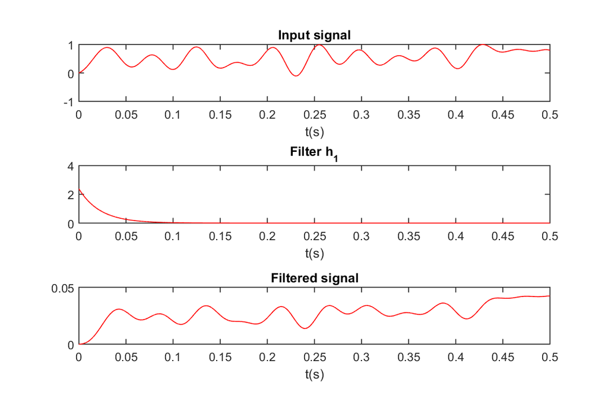

```matlab
% Relevant plots - 1. A,B,C
figure(1)
subplot(311)
plot(t,u,'r')
title('Input signal');xlabel('t(s)');
subplot(312)
plot(t,h_l1(1,:),'r')
title('Filter h_1');xlabel('t(s)');
subplot(313)
temp = conv(u,h_l1(1,:))*dt;
plot(t,temp(1:length(t)),'r')
title('Filtered signal');xlabel('t(s)')
```

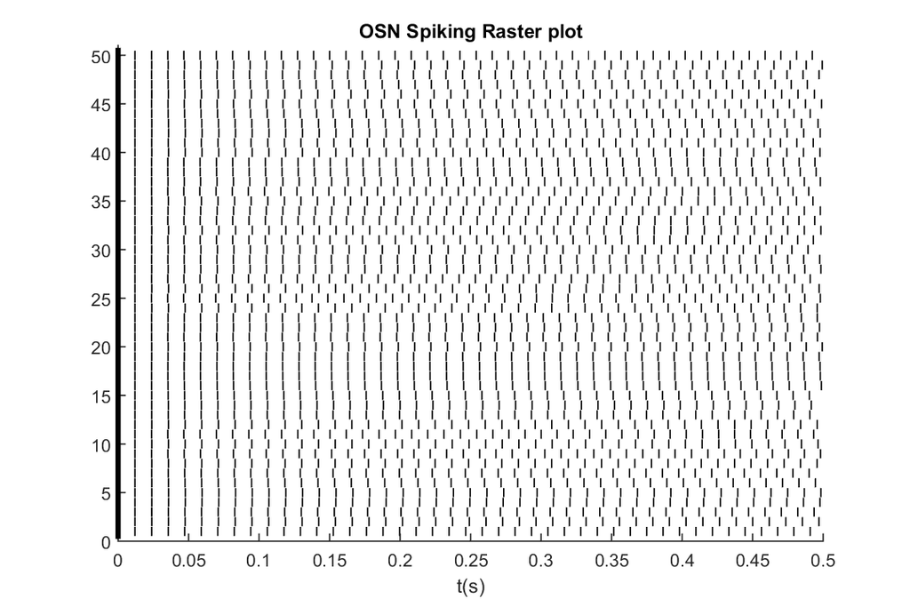

```matlab
figure(2)
utils.plotRaster(t,spike_l1)
title('OSN Spiking Raster plot')
xlabel('t(s)')
```

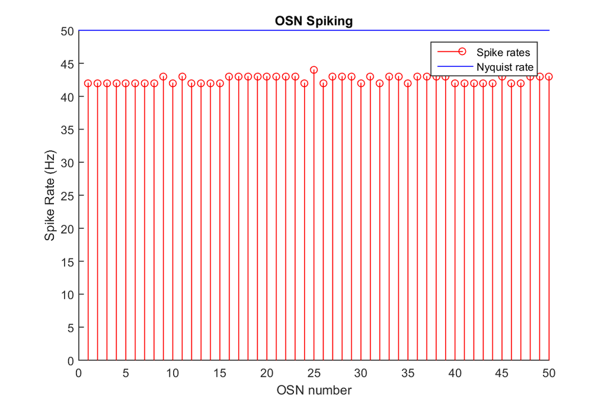

```matlab
figure(3)
hold on
stem(1:M,cellfun(@numel,tk_OSN)','r');
line([0 M],[50 50],'color','b');
xlabel('OSN number')
ylabel('Spike Rate (Hz)')
title('OSN Spiking')
legend('Spike rates','Nyquist rate')
```

```matlab
% Glomerulus
h_l2 = cell(N,M);

for i=1:N
    for j=1:M
        h_l2{i,j} = h_PN(t,1+4*rand(1),(350+100*rand(1))*1e-3);
    end
end

v_PN = zeros(N,length(t));

for i=1:N
    for j=1:M
        temp = conv(spike_l1(j,:),h_l2{i,j});
        v_PN(i,:) = v_PN(i,:) + temp(1:length(t));
    end
end
```

```matlab
% Projection Neurons
delta_l2 = 0.04*ones(N,1);
kappa_l2 = ones(N,1);
b_l2 = 1.7*ones(N,1);

tk_PN = PN(t,v_PN,b_l2,kappa_l2,delta_l2);
spkavg_l2 = sum(cellfun(@numel,tk_PN))/N;

spike_l2 = zeros(N,length(t));
for i=1:N
    spike_l2(i,round(tk_PN{i}/dt+1))=1;
end
```

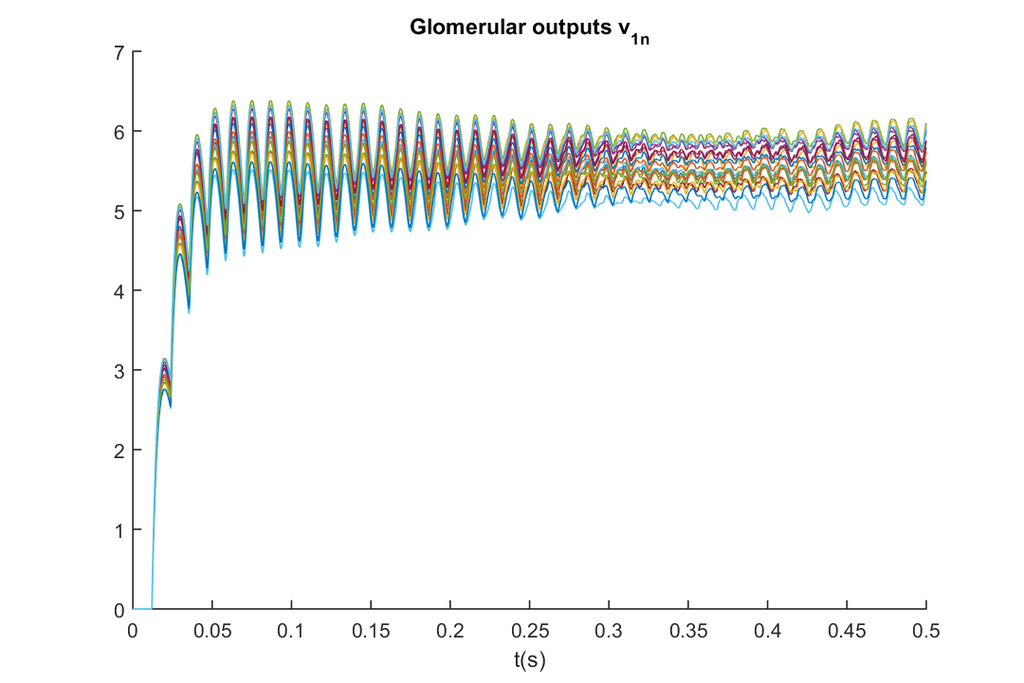

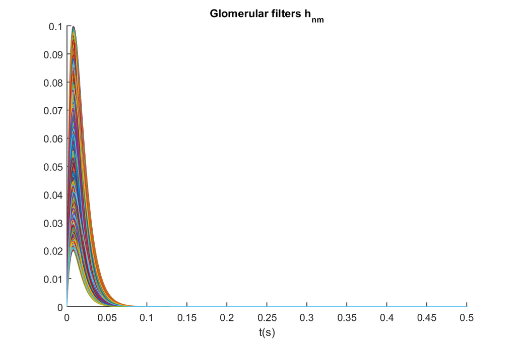

```matlab
%% Relevant Plots 1. D,E,F
figure(4)
hold on
for i=1:N
    for j=1:M
        plot(t,h_l2{i,j})
    end
end
title('Glomerular filters h_n_m');
xlabel('t(s)')

figure(5)
hold on
for i=1:N
   plot(t,v_PN(i,:))
end
title('Glomerular outputs v_1_n');
xlabel('t(s)')
```

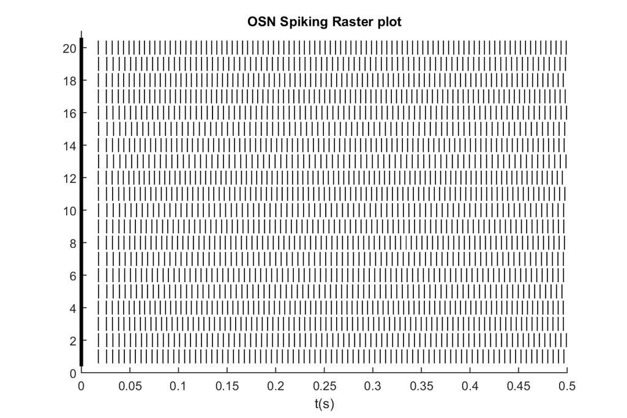

```matlab
figure(6)
utils.plotRaster(t,spike_l2)
title('OSN Spiking Raster plot')
xlabel('t(s)')
```

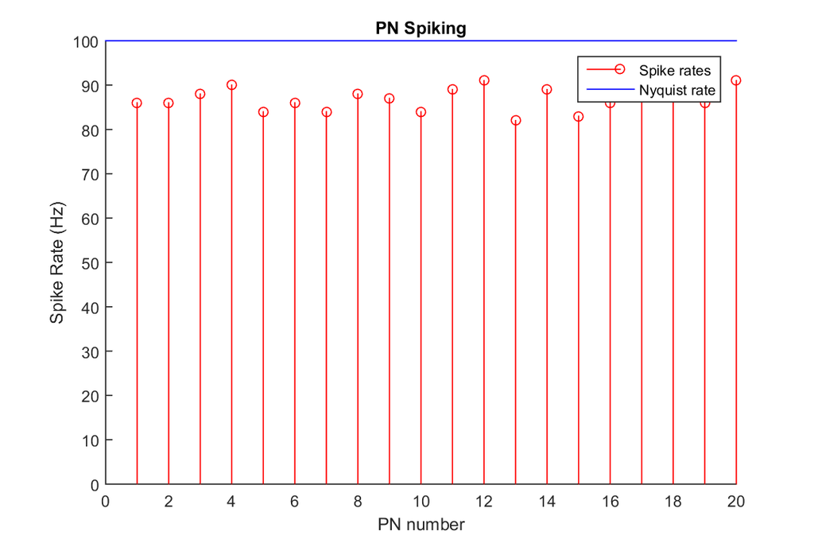

```matlab
figure(7)
hold on
stem(1:N,cellfun(@numel,tk_PN)','r');
line([0 N],[100 100],'color','b');
xlabel('PN number')
ylabel('Spike Rate (Hz)')
title('PN Spiking')
legend('Spike rates','Nyquist rate')
```

```matlab
%% 2. OSN Decoding & Recovery
dim = 0;
for i=1:M
   dim = dim+length(tk_OSN{i})-1;
end

temp = zeros(1,M+1);
for i=2:M+1         %Find out the cumulative lengths of tk
    temp(i)=temp(i-1)+length(tk_OSN{i-1})-1;
end

q_l1 = zeros(dim,1);
G_l1 = zeros(dim);

for i=1:M
    q_l1(temp(i)+1:temp(i)+length(tk_OSN{i})-1) = kappa_l1(i)*delta_l1(i) - b_l1(i)*diff(tk_OSN{i})';
end
```

```matlab
% Finding G
t_long = -0.5:dt:0.5;

for j=1:M
    cum_hg = dt*cumtrapz(dt*conv(h_l1(j,:),sinc(t_long/T)/T));
    sk = (tk_OSN{j}(1:end-1)+tk_OSN{j}(2:end))/2;
    for i =1:M
        for k = 1:length(tk_OSN{j})-1
            G_l1(temp(i)+1:temp(i)+length(tk_OSN{i})-1,temp(j)+k) = diff(cum_hg(round((tk_OSN{i} -sk(k) - t_long(1))/dt)+1));
        end
    end
end
```

```matlab
% Reconstruction
u_rec = zeros(size(t));

c = pinv(G_l1,1e-3)*q_l1;
for j=1:M
    sk = (tk_OSN{j}(1:end-1)+tk_OSN{j}(2:end))/2;
    u_rec = u_rec + signal_generator(t,c(temp(j)+1:temp(j+1)),sk',omega);
end
```

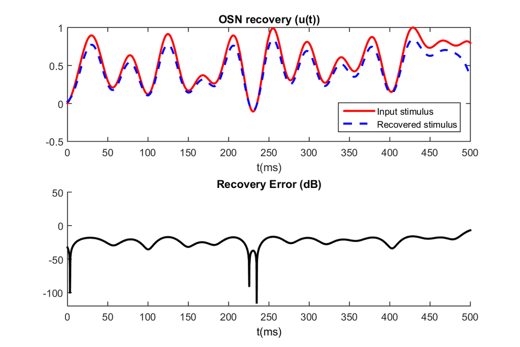

```matlab
% Relevant plots
figure('Name','Decoding OSN Stage','Color','w','Position',[10 30 1200 400]);
subplot(211);plot(1e3*t,u,'r',1e3*t,u_rec,'--b','LineWidth',2);
title('OSN recovery (u(t))'); xlabel('t(ms)')
legend('Input stimulus','Recovered stimulus','Location','SouthEast')
set(subplot(212),'ylim',[-120 50],'title',text('string','Recovery Error (dB)'),...
        'xlabel',text('string','t(ms)'))
    hold on;plot(1e3*t,mag2db(sqrt((u-u_rec).^2)),'-k','LineWidth',2);
```

```matlab
% 3. PN Decoding & Recovery
v_PN_rec = zeros(N,numel(t));
omega_new = 2*pi*100;
T_new = pi/omega_new;

for i=1:N
    q_l2 = kappa_l2(i)*delta_l2(i) - b_l2(i)*diff(tk_PN{i}');
    sk = (tk_PN{i}(2:end) + tk_PN{i}(1:end-1))/2;
    G_l2 = zeros(numel(tk_PN{i})-1);
    for j = 1:numel(sk)
        temp = dt*cumtrapz( sinc((t-sk(j))/T_new)/T_new );
        G_l2(:,j) = diff( temp( round( (tk_PN{i}-t(1))/dt )+1 ) );
    end

    c = pinv(G_l2,1e-6)*q_l2;

    v_PN_rec(i,:) = signal_generator(t,c,sk',omega_new);
end
```

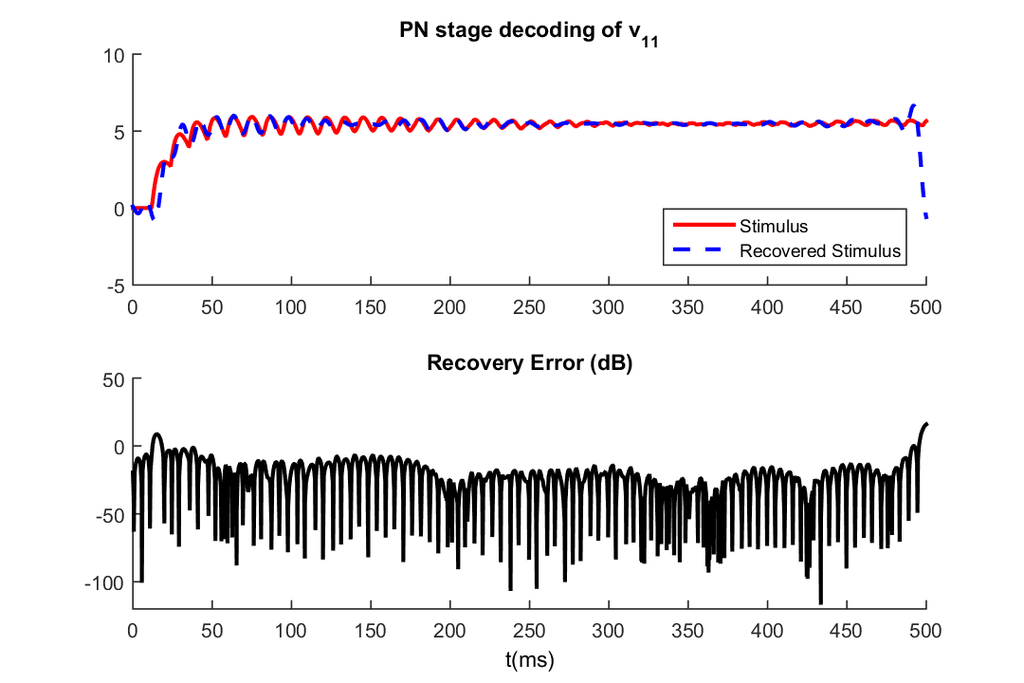

```matlab
% Relevant plots 3. A,B
figure('Name','Decoding PN Stage','Color','w','Position',[10 30 1200 400]);
    set(subplot(2,1,1),'title',text('string',{'PN stage decoding of v_1_1',}));
    hold on;plot(1e3*t,v_PN(1,:),'r',1e3*t,v_PN_rec(1,:),'--b','LineWidth',2);
    legend('Stimulus','Recovered Stimulus','Location','SouthEast');
    set(subplot(2,1,2),'ylim',[-120 50],'title',text('string','Recovery Error (dB)'),...
        'xlabel',text('string','t(ms)'))
    hold on;plot(1e3*t,mag2db(sqrt((v_PN(1,:)-v_PN_rec(1,:)).^2)),'-k','LineWidth',2);
```

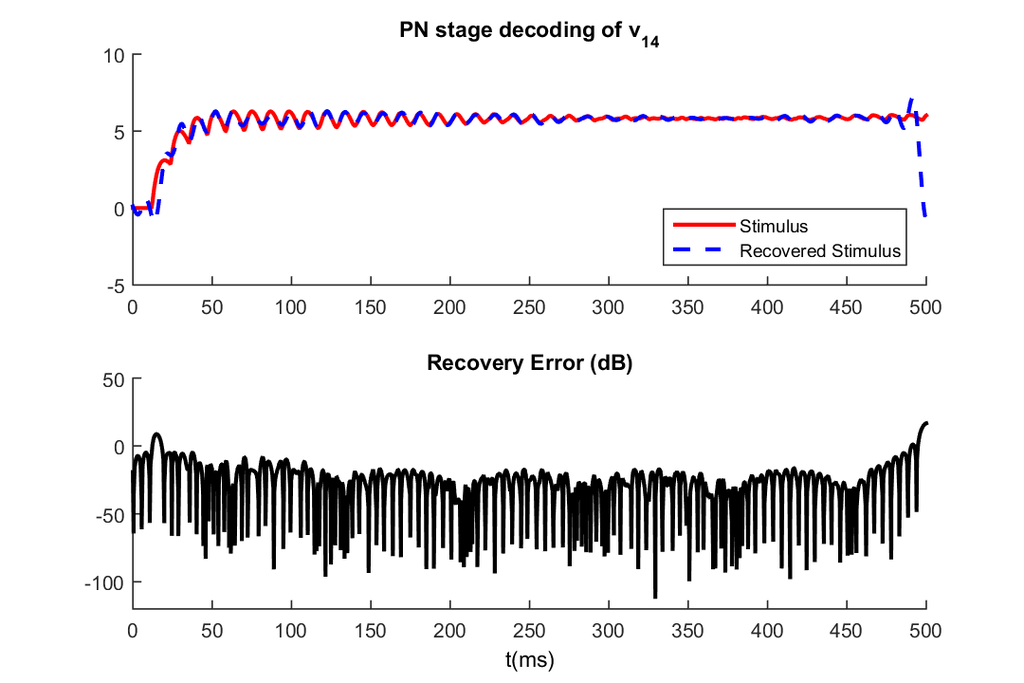

```matlab
figure('Name','Decoding PN Stage','Color','w','Position',[10 30 1200 400]);
    set(subplot(2,1,1),'title',text('string',{'PN stage decoding of v_1_4',}));
    hold on;plot(1e3*t,v_PN(4,:),'r',1e3*t,v_PN_rec(4,:),'--b','LineWidth',2);
    legend('Stimulus','Recovered Stimulus','Location','SouthEast');
    set(subplot(2,1,2),'ylim',[-120 50],'title',text('string','Recovery Error (dB)'),...
        'xlabel',text('string','t(ms)'))
    hold on;plot(1e3*t,mag2db(sqrt((v_PN(4,:)-v_PN_rec(4,:)).^2)),'-k','LineWidth',2);
```

```matlab
% 4. Parallel Filters
u_fft = fft(u,numel(t))/numel(t);
v_PN_fft = zeros(N,numel(t));
h_rec = zeros(N,numel(t));
f = 0:1/dt/numel(t):1/dt/2-1/dt/numel(t);

for i=1:1
   v_PN_fft(i,:) = fft(v_PN(i,:),numel(t))/numel(t);
   h_fft = v_PN_fft(i,:)./u_fft;
   h_rec(i,:) = ifft(h_fft);
end
```

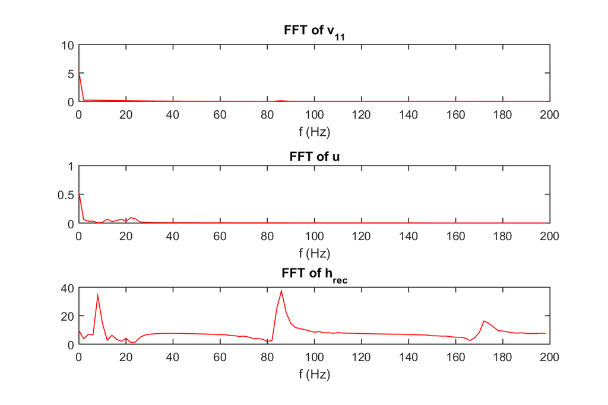

```matlab
figure;
subplot(311)
plot(f(1:100),abs(v_PN_fft(1,1:length(f(1:100)))),'r');
xlabel('f (Hz)'); title('FFT of v_1_1');
subplot(312)
plot(f(1:100),abs(u_fft(1:length(f(1:100)))),'r');
xlabel('f (Hz)'); title('FFT of u');
subplot(313)
plot(f(1:100),abs(h_fft(1:length(f(1:100)))),'r');
xlabel('f (Hz)'); title('FFT of h_r_e_c');
```

```matlab
% 5. End-to-End Recovery
dim = 0;
for i=1:N
   dim = dim+length(tk_PN{i})-1;
end

temp = zeros(1,N+1);
for i=2:N+1         %Find out the cumulative lengths of tk
    temp(i)=temp(i-1)+length(tk_PN{i-1})-1;
end

q = zeros(dim,1);
G = zeros(dim);

for i=1:N
    q(temp(i)+1:temp(i)+length(tk_PN{i})-1) = kappa_l2(i)*delta_l2(i) - b_l2(i)*diff(tk_PN{i})';
end

t_long = -0.5:dt:0.5;

for j=1:N
    cum_hg = dt*cumtrapz(dt*conv(h_rec(j,:),sinc(t_long/T)/T));
    sk = (tk_PN{j}(1:end-1)+tk_PN{j}(2:end))/2;
    for i =1:N
        for k = 1:length(tk_OSN{j})-1
            G(temp(i)+1:temp(i)+length(tk_PN{i})-1,temp(j)+k) = diff(cum_hg(round((tk_PN{i} -sk(k) - t_long(1))/dt)+1));
        end
    end
end
```

```matlab
% Reconstruction
u_rec_e2e = zeros(size(t));

c = pinv(G,1e-3)*q;
for j=1:N
    sk = (tk_PN{j}(1:end-1)+tk_PN{j}(2:end))/2;
    u_rec_e2e = u_rec_e2e + signal_generator(t,c(temp(j)+1:temp(j+1)),sk',omega)/2e2;
end
```

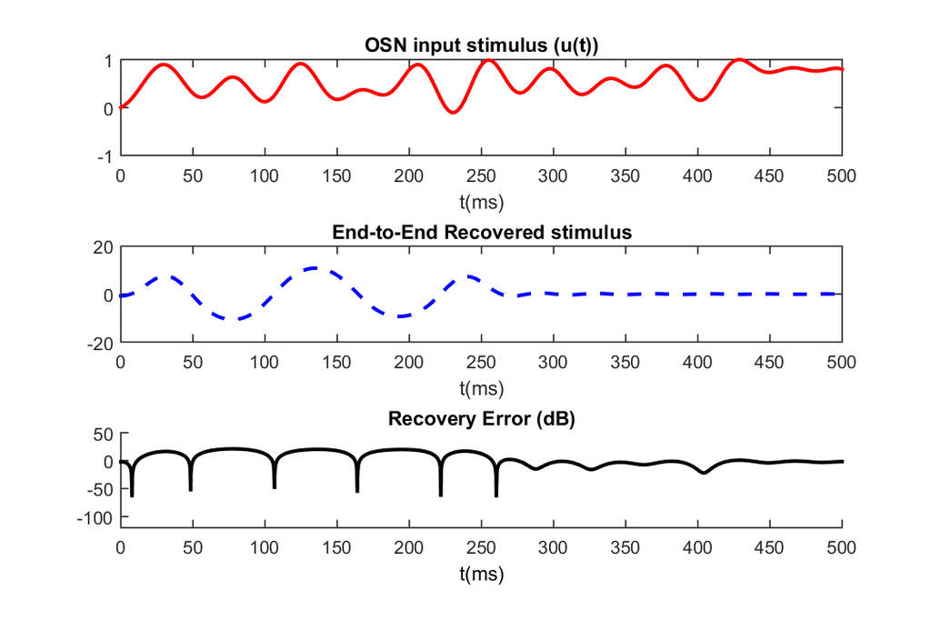

```matlab
% Relevant plots 5. A,B
figure('Name','End-to-End Recovery','Color','w','Position',[10 30 1200 400]);
subplot(311);plot(1e3*t,u,'r','LineWidth',2);
title('OSN input stimulus (u(t))'); xlabel('t(ms)')
subplot(312);plot(1e3*t,u_rec_e2e,'--b','LineWidth',2);
title('End-to-End Recovered stimulus'); xlabel('t(ms)')
set(subplot(313),'ylim',[-120 50],'title',text('string','Recovery Error (dB)'),...
        'xlabel',text('string','t(ms)'))
    hold on;plot(1e3*t,mag2db(sqrt((u-u_rec_e2e).^2)),'-k','LineWidth',2);
```

As is evident from the above plot, the end-to-end recovery did not perform very well. In fact, the recovered stimulus is not even in the same range as the input stimulus. The main reason for this is that due to the structure of the glomerulus and the and mixing of spiking activity of different OSNs, the parallelization approximation is invalid, and the hypothetical filters $\tilde{h}_{1n}$ do not model the OSN + Glomerulus well. This problem also stems from the fact that we are replacing a highly non-linear OSN spiking followed by glomerulus with a linear filter bank. Thus, while we can recover u from tk_OSN using $h_m$, we can't recover u from tk_PN using the hypothetical parallelized filters.

In the code, this problem manifests in the form that the coefficients of G are too small, and to be able to invert it without having the resulting values blow up, we have to set high tolerance values (~1e-2,1e-3), and therefore, the c matrix is highly inaccurate. Consequently, the high $c_k$ values lead to high scaling of basis sinc functions, and ultimately the range of the reconstructed signal blows up.